# Decoupled wood and leaf strategies among canopy and understorey tree in a low-elevation rainforest of India

Sylvain Schmitt sylvain.schmitt@agroparistech.fr

2018-01-25

# Abstract

## Keywords

functional trait; rainforest; vertical forest strata; Western Ghats; environmental filtering; niche differentiation; ecological guild

# Introduction

Understanding the determinants of species occurrence and co-occurrence is a long standing issue in ecology (Diamond 1975). Tropical rainforests have especially fascinated ecologists due to their outstanding diversity (Connell 1978). Niche theory explains species coexistence through niche differences that limit competitive exclusion (Weiher & Keddy 1995; Lortie *et al.* 2004), while neutral theory shows that maintenance of high diversity is possible even for functionally equivalent species, under the influence of stochastic life, death, reproduction and dispersal dynamics (Hubbell 2001). Both theories can provide realistic expectations of taxonomic diversity (Chave *et al.* 2002) so that inferring ecological processes from taxonomical composition pattern is challenging in community ecology.

Investigating patterns of functional or phylogenetic diversity may reveal signatures of ecological processes that are specific to the niche theory (Mcgill *et al.* 2006; Westoby & Wright 2006; Mouquet *et al.* 2012). Indeed, if taxonomic composition is expected to be spatially structured in both theories, due to the spatial structure of environment or to dispersal limitation, functional or phylogenetic assemblage are expected to be spatially structured only under the niche theory (Kraft & Ackerly 2010; Baraloto *et al.* 2012; Hardy *et al.* 2012; Parmentier *et al.* 2014).

The variation in functional traits among species is expected to reflect different abilities to grow, survive and reproduce in a given environment (Violle *et al.* 2007) and expresses fundamental trade-offs along environmental gradients (Westoby *et al.* 2002). For instance, specific leaf area varies along the soil fertility-shade gradient and represents a trade-off between resource acquisition by photosynthesis and investment in leaf defense and durability (Hodgson *et al.* 2011). Fundamental trade-offs entail functional traits covariation along basic leaf (Wright *et al.* 2004 but see Osnas *et al.* (2013) and Lloyd *et al.* (2013)) and wood (Chave *et al.* 2009) economics spectra. The leaf economics spectrum opposes acquisitive to conservative ecological strategies, basically expressed at leaf level. The wood economics spectrum distinguishes species strategies over three axes spanning the basic CSR strategies of Grime (1977) : (i) competitive species, with high conductive efficiency, (ii) stress tolerant species, resistant to embolism, and (iii) disturbance tolerant species, with high mechanical strength (Chave *et al.* 2009). Baraloto *et al.* (2010) found decoupled wood and leaf economics of trees in neotropical forest, but Reich (2014) conversely posited that both spectra have to be integrated in a comprehensive whole plant economics spectrum (Freschet *et al.* 2010) opposing fast growing acquisitive species to slow growing and more conservative ones.

The trait values of coexisting species represent a non-random sample of trait values found in a broader area, du to specific niche-based dynamics in the local community (Lortie *et al.* 2004; Bernard-Verdier *et al.* 2012). Then the signature of local niche-based dynamics can be gasped by assessing the deviation of local community structure from a larger “species pool”, classicaly using null models (Kraft *et al.* 2008). In addition, the nature of functional traits and ecological strategies driving species coexistence can change across scales. For instance, Messier *et al.* (2016) have underlined that the leaf economics spectrum basically expresses changes in ecological strategies along broad-scale environmental gradients, while it is not necessarily a primary driver of local coexistence.

The concept of guilds refer to groups of functionally similar species (Wilson 1999). Ecological guilds can coexist and occupy distinct niches within communities (Vergnon *et al.* 2009). In tropical forests, the assembly of tree communities has been mostly studied irrespectivelly of guilds of canopy and understorey tree (Wright 2002). However, distinctive ecological constraints are expected to drive different resource use strategies and biotic interactions in these guilds, which should translate into different functional composition and response to environmental factors. For instance, in Colombian Amazonie, Duque *et al.* (2002) found some contrasted response of the composition of canopy and understorey guilds along environmental gradients.

In this paper, we used a trait-based approach to study separately the assembly of canopy and understorey tree species along topographical and biotic gradients in a large forest plot (10ha) loacted in Western Ghats biodiversity hotspot (Myers *et al.* 2000), India. Low elevation rainforests in South India are remarkably heterogeneous in vertical structure and encompass distinctive guilds across the vertical strata (Pascal 1988). It thus provides an appropriate context to adress guild-dependent assembly rules and ecological strategies in tropical rainforests. Although considered as wet evergreen, the forest undergoes contrasted long dry and intense rainy seasons under the influence of monsoon. In this context, we expected water stress and competition for resource to be important drivers of tree functional composition. We investigated how both canopy and understorey tree species composition varied with local environmental conditions, using appropriate null models. We specifically addressed the following questions:

- Does functional traits variation and covariation reflect basic dimensions of ecological strategy in the rainforest ?
- Does local functional composition from guilds differ ?
- Does the local functional composition reflect the influence of abiotic and biotic drivers of community dynamics within guilds ?

# Material and methods

## Study site

The study was carried out in a 10-ha permanent plot established in 1990 by the French Institute of Pondicherry in an undisturbed, old-growth wet evergreen Dipterocarp forest (Pascal & Pelissier 1996). The plot is located in the Kadamakal Reserve Forest (Kodagu District, Karnataka State, India), near the Uppangala village, and thus refers to as “Uppangala plot”. Annual precipitation averages 5108 mm per year but is highly variable in time with heavy rainfall from June to October (90% of the rainfall during the monsoon) and a severe dry season (monthly rainfall $\leq 45$ mm) lasting 3.8 months (Pélissier *et al.* 2011). Mean annual temperature in the station of Sampaji (15 km from Uppangala) is about 27$^\circ C$, with a mean minimum about 25$^\circ C$ during July rainfall pick and a maximum mean temperature of 29$^\circ C$ in April (Pascal & Pelissier 1996). Climate and geology of the 10-ha plot can be considered as homogeneous. The topography of the site is highly heterogeneous with regular east-west alternation of thalwegs and ridges separated by steep slopes, so that topography is expected to be a major component of environmental variation within the forest plot (Gimaret-Carpentier *et al.* 1998). Therefore, we hypothesized that topographic variation should influence community assembly and yield changing ecological strategies and functional composition (Condit *et al.* 2000).

## Taxonomic composition and trait sampling

From 1989 to 2014, the trees $\geq 10$ cm in diameter at breast height (dbh) were identified to species level, tagged, mapped and monitored in an area progressively extended to a contiguous $300 * 330 m^2$ (ca. 10-ha) plot (Pélissier *et al.* 2011). The plot included 111 different tree species. We collected trait data from 89 over 111 (80.1%) species, which represented 99.0% of tree individuals present in the plot. Note that the 32 most abundant species represented more than 80% of tree individuals. We sampled five individuals per species for these 32 species, and sampled one to five individuals for the remaining species (in total 267 individuals). For each individual we collected 5 mature shadow leaves and one branch sample with a diameter close to 1 cm following recommendation of Pérez-Harguindeguy *et al.* (2013). Individuals and leaves were selected in consistent light conditions, development stage and sanitary state. Dawkins crown exposure index (Dawkins 1958) was recorded for each tree sampled to control for any sun-exposure effect. Leaf and branch samples were kept in humidified ziplock filled with enriched $CO_{2}$ air inside a black bag until measurement within the next 24 hours. For some individuals, we were unable to collect suitable branch sample, i.e. with a diameter $\leq 1$ cm (11 missing species over 89 representing 1% of individuals present).

## Trait measurements

We calculated five functional traits of leaf and wood samples: leaf thickness (LT in $\mu m$ ), leaf area measured from scans (LA in $mm^2$), leaf dry matter content as the leaf dry weight divided by the leaf fresh weight (LDMC in $mg.g^-1$), specific leaf area as the leaf area divided by the leaf dry mass (SLA in $m^2.kg^-1$), and branch wood density as the the wood sample dry weight divided by its volume (WD in $g.cm^-3$, see table 1). We choose those five traits because they proved to be good proxies of the major dimensions of ecological strategies in plants (Westoby *et al.* 2002; Díaz *et al.* 2015) and were relatively easy to measure on the field.

Table 1: Functional traits measured. Traits with their abbreviation, standard unit, and associated species strategy for functioning, survival and reproduction (Baraloto *et al.* 2010).

| Trait | Abbreviation | Unit | Strategy |
| --- | --- | --- | --- |
| Leaf thickness | LT | $\mu m$ | Leaf defense and investment |
| Leaf area | LA | $mm^2$ | Leaf resource capture vs.investment |
| Leaf dry matter content | LDMC | $mg.g^-1$ | Leaf defense and investment |
| Specific leaf area | SLA | $m^2.kg^-1$ | Leaf resource acquisiton vs. defense |
| Wood density | WD | $g.cm^-3$ | Stem transport, structure and defense |

## Environmental variables

In order to identify the main sources of environmental variation and to avoid multi-colinearity in subsequent analyses, we performed a principal component analysis (PCA) of the abiotic environmental variables (see Supplementary materials S1: Principal component analysis of topographical variables). We selected four little-correlated variables: curvature representing local water flow paths and soil accumulation areas, wetness highlighting water accumulation areas over the whole study area, southwesterness representing aspect (Bunyan *et al.* 2015) and slope, which may have both a strong effect on forest dynamics and on nutrient/water availability (Ferry *et al.* 2010).

In addition, we selected two biotic factors related to local forest structure: canopy height and basal area. Canopy height, i.e. the maximum local height of the canopy, was calculated from a 1-m resolution digital canopy model built from a LiDAR (Light Detection And Ranging) dataset acquired in 2013 over the Uppangala plot. Basal area was calculated from the girth measurements taken within the 10-ha plot (censuses done in 2013 and 2014) for stems $\geq 10$ cm dbh.

## Analyses

### Guilds

Pascal (1988) defined four vertical strata attained by adult trees: emergent above 39m, canopy trees between 25 and 39m, sub-canopy trees between 15 and 25m, and understorey trees below 15m. Despite the vertical hierarchy, steep topography could allow sub-canopy trees receiving more light, especially in slopes, and thus participates to canopy. We thus defined two basic guilds called canopy (C), composed of emergent, canopy and sub-canopy species (n = 55), and understorey (U) species (n = 34).

### Traits variation and covariation

We first calculated the coefficient of variation (ratio of the standard deviation to the mean) of trait values among leaves of the same individual (intra-individual), among trees of the same species (intra-specific for species with more than one individual), and among species (inter-specific). We then performed a principal component analysis (PCA) of the mean value of traits per species to identify main dimensions of ecological strategies along which traits can covary among guilds. In addition we explored guilds functional signature. We used guilds functional hypervolume and tested their overlap against 999 nul hypervolume randomizing species in strata. Subsequent community-level analyses were based on trait values averaged per species.

### Drivers of community dynamics

We subdivided the 10-ha plot into $30*30 m^2$ quadrats leading to 110 local communities. We analyzed the functionnal composition of the guilds in the 110 communities. Guilds in the communities have a mean number of 28 individuals representing 10 species, with less in understorey than in canopy.

We calculated weighted mean (GWM, where G stands for “guild”) and weighted variance (GWV) (GWM and GWV, Violle *et al.* 2007) for each guild in each community. In the quadrat $j$, GWM of trait $t$ was the mean of trait values $t_{i}$ of species $i$ weighted by species relative abundance $p_{i}$:
$$GWM_{j} = \sum_{i=1}^{S} p_{i,j} * t_{i,j} ~ (1)$$
where $S$ is the number of species in the quadrat $j$. We also calculated the average trait values based on presence-absence values to assess the influence of less abundant and rare species on community trait composition (Cingolani *et al.* 2007). GWV of trait $t$ was calculated as :
$$GWV_{j} = \sum_{i=1}^{S} p_{i,j} * (t_{i,j} - GWM_{j})^2 ~ (2)$$

To test for any significant changes in functional composition, we devised a null model approach. We thus explored following questions with subsequent hypothesis:

- **Q1** Does local functional composition from guilds differ ?
  - **H1a** Environmental filtering differ in selection of local functional composition between canopy and understorey species.
  - **H1b** Environmental filtering strenght differ locally between canopy and understorey species.
- **Q2** Does the local functional composition reflect the influence of abiotic and biotic drivers of community dynamics within guilds ?
  - **H2a** Drivers of environmental filtering on local functional composition differ between canopy and understorey tree species.
  - **H2b** Strength of drivers of evironmental filtering differ between canopy and understorey tree species.

To accept or reject hypothesis we used three null models :

- **NM1** randomized species among guilds. Consequently, NM1 breaks the link between species and guilds while keeping community structure, thus testing for hypothesis **H1a**.
- **NM2** randomized trait values among species in the whole plot for each guild (permuting raw in `Trait*Species` matrices of both guilds) (Bernard-Verdier *et al.* 2012). Consequently, NM2 breaks the link between environement and local functional composition while keeping guilds and species spatial structure, thus testing for hypothesis **H2a**.
- **NM3** randomized abundances among species within each guild but kept the observed list of species and trait values unchanged inside guilds (Bernard-Verdier *et al.* 2012). Consequently NM3, breaks the link between environment and species abundances while keeping guilds, community, and species spatial structure, thus testing for hypothesis **H1b** and **H2b**.

To characterize the patterns of deviation from the null model, we also calculated standardized effect sizes (SES) as
$$SES = \frac{(I_{obs} - I_{null})}{\sigma _{null}} (2)$$
where $I_{obs}$ was the observed metric and $I_{null}$ and $\sigma _{null}$ were the mean and standard deviation of the corresponding null distribution. The influence of environment on SES values was investigated by linear regression with biotic and abiotic factors ($SES_{trait} = Slope + Curvature + Wetness + SW + Canopy + BA$). Analyses were conducted on the five functional traits.

All analyses were conducted using the R 3.3.0 software (R Core Team 2016) with packages `ade4` (Dray *et al.* 2007), and `vegan` (Oksanen *et al.* 2016).

# Results

## Traits variation and covariation

Table 2: Intra-individual, intra-specific and inter-specific component of trait variation. The overall range, mean and standard deviation are provided for each trait. The remaining columns represent the coefficient of variation of trait values among leaves per individuals (intra-individual), among trees per species (intra-specific), and among trees of different species. See table 1 for abbreviation.

| trait | min | max | mean | sd | Intra-individuals | Intra-species | Inter-species |
| --- | --- | --- | --- | --- | --- | --- | --- |
| WD | 0.34 | 0.84 | 0.61 | 0.10 | 0.00 | 0.07 | 0.20 |
| LT | 12.00 | 61.00 | 22.94 | 5.82 | 0.06 | 0.11 | 0.25 |
| LA | 392.49 | 217327.87 | 12234.89 | 13863.76 | 0.20 | 0.25 | 1.23 |
| LDMC | 146.15 | 666.67 | 380.21 | 88.61 | 0.07 | 0.11 | 0.21 |
| SLA | 3.63 | 43.27 | 13.92 | 3.97 | 0.09 | 0.14 | 0.32 |

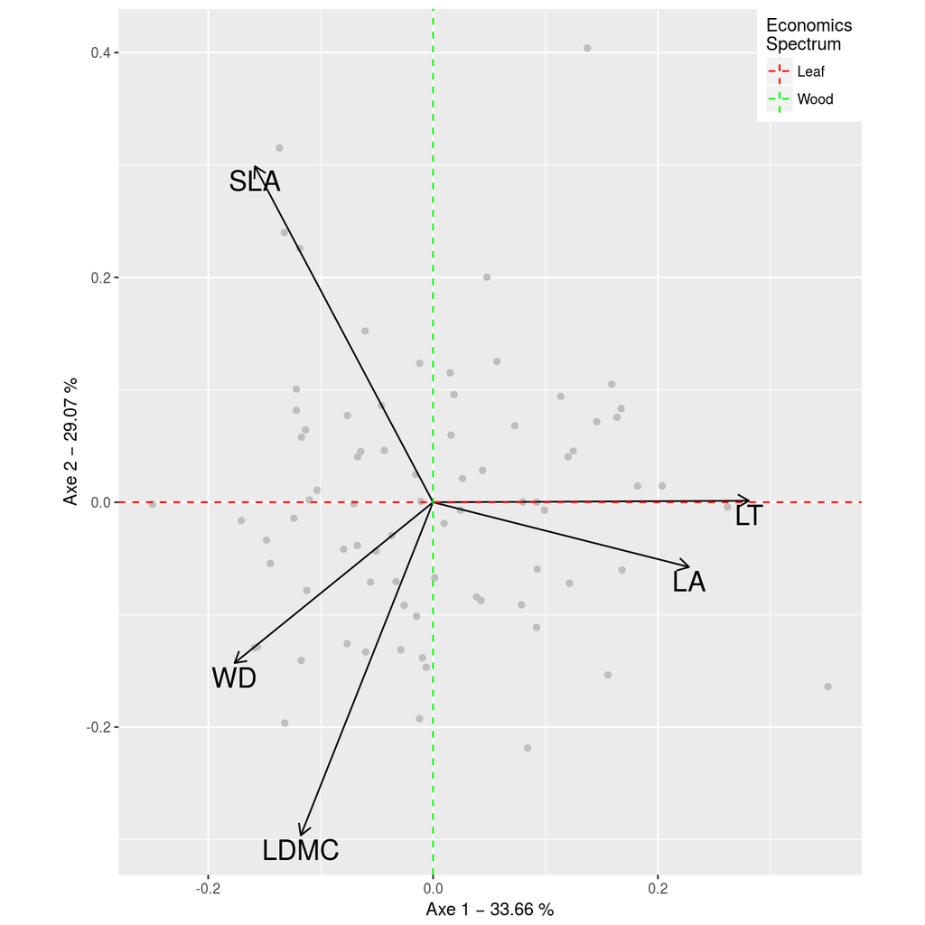

## Functional composition of guilds

### *Does local functional composition from guilds differ ?*

#### H1a. Environmental filtering differ in selection of local functional composition between canopy and understorey species

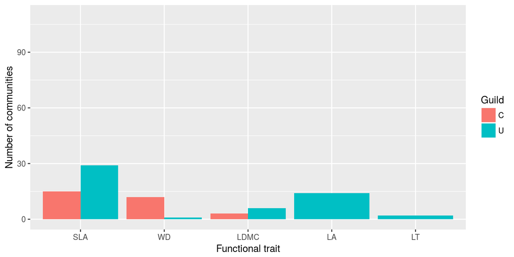

Figure 2: Number of communities significantly (p-value<0.05) different from null expectations with null model NM1 for each trait of GWMs, for canopy (C) and understorey (U) guilds, in abundance. See table 1 for abbreviations.

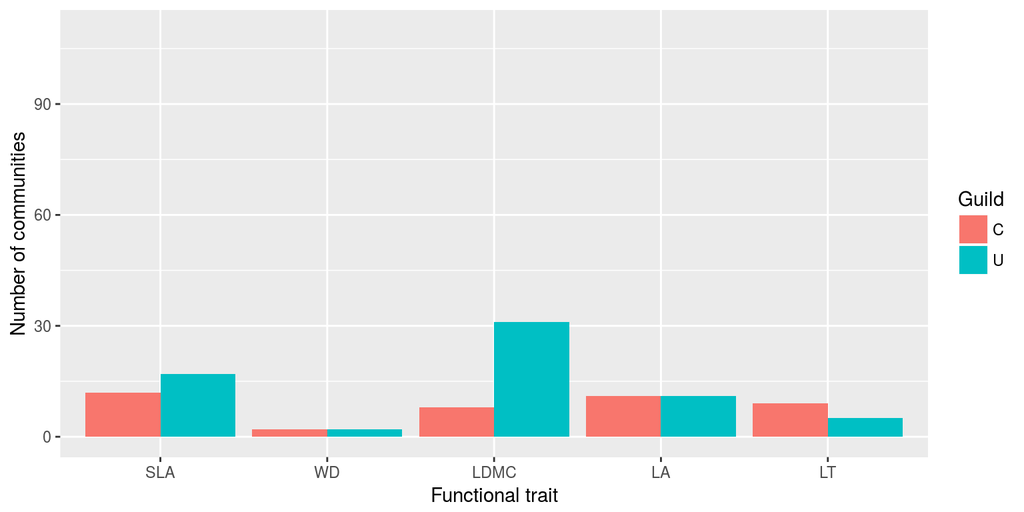

Figure 3: Number of communities significantly (p-value<0.05) different from null expectations with null model NM3 for each trait of GWVs, for canopy (C) and understorey (U) guilds, in abundance. See table 1 for abbreviations.

### *Does the local functional composition reflect the influence of abiotic and biotic drivers of community dynamics within guilds ?*

#### H2a. Drivers of environmental filtering on local functional composition differ between canopy and understorey tree species

Table 3: Linear models of the standardized effect size (SES) with null model NM2 for each trait of GWMs, for canopy (C) and understorey (U) guilds, in abundance. We performed stepwise selection of the predictors including slope, curvature, wetness southwesterness (SW), canopy height (Canopy) and basal area (BA), and only the selected predictors are shown. See table 1 for abbreviations. Bold and number of asterisk indicates the significance threshold ( * p-value<0.05, ** p-value <0.01, *** p-value<0.001).

| strata | trait | Slope | Curvature | Wetness | SW | Canopy | BA |
| --- | --- | --- | --- | --- | --- | --- | --- |
| C | SLA | -8.5e-03 . | -1.6e+00 | -1.5e-01 . |  | -9.3e-03 . |  |
| C | WD |  | **1.4e+01 ***** |  | **3e-01 *** |  |  |
| C | LDMC |  |  | -2.5e-01 . |  |  |  |
| C | LA |  | **-5.5e+00 **** |  | **-2.1e-01 *** | **1.9e-02 *** |  |
| C | LT | 1.3e-02 . | 2.7e+00 |  |  |  |  |
| U | SLA |  | **-1e+01 ***** | **-1.8e-01 *** |  | **3e-02 ***** | -5.7e-06 |
| U | WD | 9.4e-03 . |  | **-2.7e-01 **** | 1.2e-01 . |  |  |
| U | LDMC | -8.7e-03 . | 2e+00 . |  |  |  |  |
| U | LA |  |  | **3.5e-01 *** |  |  |  |
| U | LT |  | **6.7e+00 ***** | **2e-01 *** |  | **-1.6e-02 *** |  |

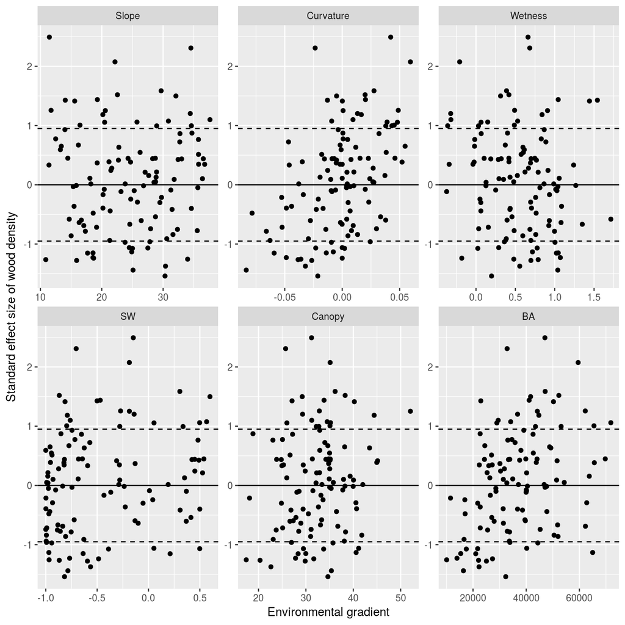

Figure 4: Exemple of standard effect size (SES) of wood density (WD) for canopy (C) tree species. Each subplot show standard effect size (SES) with null model NM2 of wood density (WD) for canopy (C) tree species along one environmental variable gradient. Continuous line represents a null SES, whereas dashed line represents limits of the confidence interval above which SES are considered as significant. See table 1 for abbreviation.

#### H2b. Strength of drivers of evironmental filtering differ between canopy and understorey tree species

Table 4: Linear models of the standardized effect sizes (SES) with null model NM3 of GWV for canopy (C) and understorey (U) guilds. We performed stepwise selection of the predictors including slope, curvature, wetness southwesterness (SW), canopy height (Canopy) and basal area (BA), and only the selected predictors are shown. See table 1 for abbreviations. Bold and number of asterisk indicates the significance threshold ( * p-value<0.05, ** p-value <0.01, *** p-value<0.001).

| strata | trait | Slope | Curvature | Wetness | SW | Canopy | BA |
| --- | --- | --- | --- | --- | --- | --- | --- |
| C | SLA |  | -4.9e+00 . | **-3.1e-01 *** |  |  | **1.4e-05 **** |
| C | WD |  |  | **-4.4e-01 **** |  |  |  |
| C | LDMC |  | **7.3e+00 **** |  |  | **-2.3e-02 *** |  |
| C | LA |  |  | -2.1e-01 |  | -2e-02 . | 7.4e-06 |
| C | LT |  |  |  |  |  |  |
| U | SLA |  |  |  |  |  | **9.8e-06 *** |
| U | WD |  |  | **4.1e-01 ***** | -1.6e-01 . |  |  |
| U | LDMC |  |  |  | **-1.4e-01 *** |  |  |
| U | LA |  |  | **-4.3e-01 *** |  |  |  |
| U | LT |  |  |  |  |  |  |

# Discussion

## **“Take home messages” to add :**

- **Pantropical and multiscale WES and LES ?**
- **Decoupled wood and leaf strategies among canopy and understorey tree species**
- **WES among canopy tree species**
- **LES among understorey tree species**

## Environment influence guild-level functionnal composition

The influence of aspect on forest composition is little documented in tropical forests. In a similar context that our study site, Gunatilleke *et al.* (2006) gave some intuitive insights on the effect of aspect on forest composition: he suggested that aspect through monsoon had a potential effect on rainforests. Bunyan *et al.* (2015) tested the effect of aspect on the occurence of forest fragments in a forest-grassland mosaic and foud that southwest orientation strongly determined the presence of forest in mountain rainforests of Western Ghats. They suggested that it could result from monsoon winds. In our context, monsoon winds are south-west oriented, and are expected to be a major source of disturbance in forests (Soman & Kumar 1990).

The Uppangala plot is situated in a topographically complex area with steep slopes mostly organized along southwest-oriented crests. In this context it is diffcult to predict wind flow and orientation inside the 10-ha plot topography. We propose two explanation, hardwood could be selected for mechanical resistance in more disturbed souwhtwest oriented area or topography provoke a turbulences on northeast oriented areas responsible of more disturbance and death events in the forest history resulting in lightwood filtering (Larjavaara & Muller-Landau 2010). In both case it seems reasonable that canopy tree species are the most influenced by disturbance events linked to monsoon, and may even buffer the effect on understorey species.

# *Acknowledgement*

- French Institute of Pondicherry (FIP)
- Cedric Vega for the extension of the plot

# Supplementary materials

## S1: Principal component analysis of topographical variables

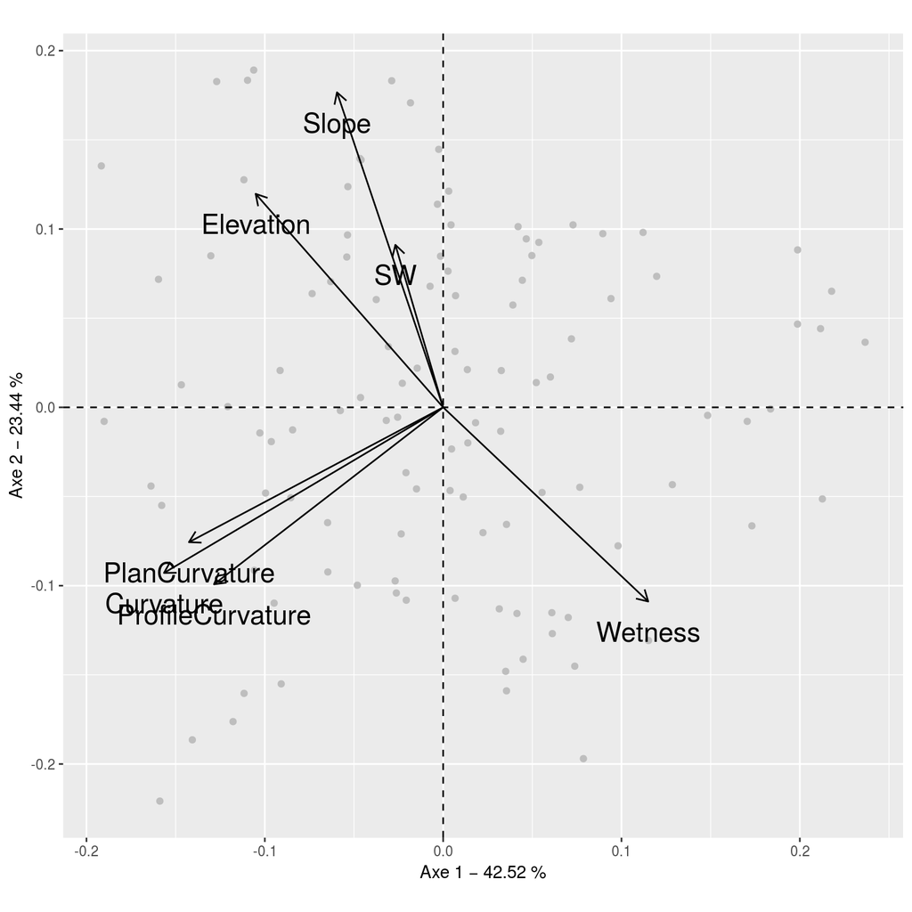

Figure 5: Principal component analysis (PCA) performed on topgraphical variables. SW stand for southwesterness.

## S2: Hypervolumes of functional guilds

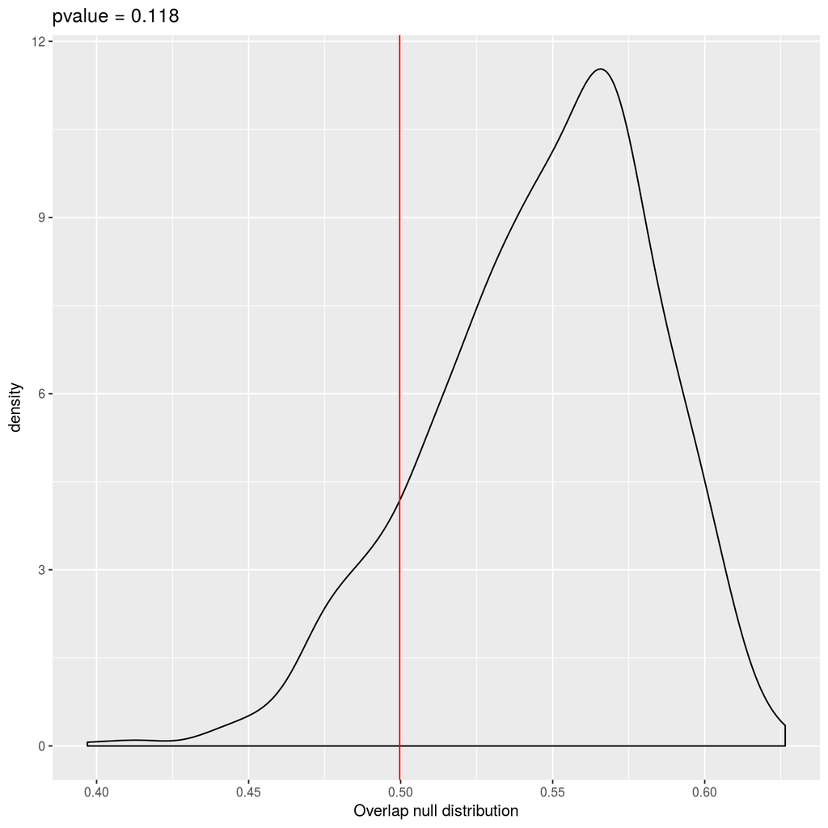

Figure 6: Functional hypervolume overlap of canopy and understorey species.

Table 5: means of hypervolumes functional traits

|  | SLA | WD | LDMC | LA | LT |
| --- | --- | --- | --- | --- | --- |
| C | 2.719358 | 0.5672615 | 363.9467 | 9.929381 | 26.53667 |
| U | 2.721321 | 0.5576770 | 363.9997 | 9.033358 | 27.30000 |
| Intersect | 2.665790 | 0.5884197 | 372.2001 | 9.179766 | 24.14821 |

# References

Baraloto, C., Hardy, O.J., Paine, C.E.T., Dexter, K.G., Cruaud, C., Dunning, L.T., Gonzalez, M.-A., Molino, J.-F., Sabatier, D., Savolainen, V. & Chave, J. (2012). Using functional traits and phylogenetic trees to examine the assembly of tropical tree communities. *Journal of Ecology*, **100**, 690–701.

Baraloto, C., Timothy Paine, C.E., Poorter, L., Beauchene, J., Bonal, D., Domenach, A.-M., Hérault, B., Patiño, S., Roggy, J.-C. & Chave, J. (2010). Decoupled leaf and stem economics in rain forest trees: Decoupled leaf and stem economics spectra. *Ecology Letters*, **13**, 1338–1347.

Bernard-Verdier, M., Navas, M.-L., Vellend, M., Violle, C., Fayolle, A. & Garnier, E. (2012). Community assembly along a soil depth gradient: Contrasting patterns of plant trait convergence and divergence in a Mediterranean rangeland. *Journal of Ecology*, **100**, 1422–1433.

Brenning, A. (2008). Statistical geocomputing combining R and SAGA: The example of landslide susceptibility analysis with generalized additive models. *SAGA – Seconds Out (= Hamburger Beitraege zur Physischen Geographie und Landschaftsoekologie, vol. 19)*, pp. 23–32. J. Boehner, T. Blaschke, L. Montanarella.

Bunyan, M., Bardhan, S., Singh, A. & Jose, S. (2015). Effect of topography on the distribution of tropical montane forest fragments: A predictive modelling approach. *Journal of Tropical Forest Science*, **27**, 30–38.

Chave, J., Coomes, D., Jansen, S., Lewis, S.L., Swenson, N.G. & Zanne, A.E. (2009). Towards a worldwide wood economics spectrum. *Ecology Letters*, **12**, 351–366.

Chave, J., Muller-Landau, H.C. & Levin, S.A. (2002). Comparing classical community models: Theoretical consequences for patterns of diversity. *The American Naturalist*, **159**, 1–23.

Cingolani, A.M., Cabido, M., Gurvich, D.E., Renison, D. & Díaz, S. (2007). Filtering processes in the assembly of plant communities: Are species presence and abundance driven by the same traits? *Journal of Vegetation Science*, **18**, 911–920.

Condit, R., Ashton, P.S., Baker, P., Bunyavejchewin, S., Gunatilleke, S., Gunatilleke, N., Hubbell, S.P., Foster, R.B., Itoh, A., LaFrankie, J.V. & others. (2000). Spatial patterns in the distribution of tropical tree species. *Science*, **288**, 1414–1418.

Connell, J.H. (1978). Diversity in tropical rain forests and coral reefs. *Science*, **199**, 1302–1310.

Dawkins, H.C. (1958). *The management of nature tropical high-forest with special reference to Uganda*.

Diamond, M. (1975). *Ecology and evolution of communites*. The Belknap press of Harvard university press.

Díaz, S., Kattge, J., Cornelissen, J.H.C., Wright, I.J., Lavorel, S., Dray, S., Reu, B., Kleyer, M., Wirth, C., Colin Prentice, I., Garnier, E., Bönisch, G., Westoby, M., Poorter, H., Reich, P.B., Moles, A.T., Dickie, J., Gillison, A.N., Zanne, A.E., Chave, J., Joseph Wright, S., Sheremet’ev, S.N., Jactel, H., Baraloto, C., Cerabolini, B., Pierce, S., Shipley, B., Kirkup, D., Casanoves, F., Joswig, J.S., Günther, A., Falczuk, V., Rüger, N., Mahecha, M.D. & Gorné, L.D. (2015). The global spectrum of plant form and function. *Nature*, **529**, 167–171.

Dray, S., Dufour, A.-B. & others. (2007). The ade4 package: Implementing the duality diagram for ecologists. *Journal of statistical software*, **22**, 1–20.

Duque, A., Sánchez, M., Cavelier, J. & Duivenvoorden, J.F. (2002). Different floristic patterns of woody understorey and canopy plants in colombian amazonia. *Journal of Tropical Ecology*, **18**, 499–525.

Ferry, B., Morneau, F., Bontemps, J.-D., Blanc, L. & Freycon, V. (2010). Higher treefall rates on slopes and waterlogged soils result in lower stand biomass and productivity in a tropical rain forest. *Journal of ecology*, **98**, 106–116.

Fortunel, C., Fine, P.V.A. & Baraloto, C. (2012). Leaf, stem and root tissue strategies across 758 Neotropical tree species. *Functional Ecology*, **26**, 1153–1161.

Freschet, G.T., Cornelissen, J.H.C., Van Logtestijn, R.S.P. & Aerts, R. (2010). Evidence of the ‘plant economics spectrum’ in a subarctic flora. *Journal of Ecology*, **98**, 362–373.

Gimaret-Carpentier, C., Pélissier, R., Pascal, J.-P. & Houllier, F. (1998). Sampling strategies for the assessment of tree species diversity. *Journal of Vegetation Science*, **9**, 161–172.

Grime, J.P. (1977). Evidence for the Existence of Three Primary Strategies in Plants and Its Relevance to Ecological and Evolutionary Theory. *The American Naturalist*, **111**, 1169–1194.

Gunatilleke, C.V.S., Gunatilleke, I.A.U.N., Esufali, S., Harms, K.E., Ashton, P.M.S., Burslem, D.F.R.P. & Ashton, P.S. (2006). Species–habitat associations in a Sri Lankan dipterocarp forest. *Journal of Tropical Ecology*, **22**, 371.

Hardy, O.J., Couteron, P., Munoz, F., Ramesh, B.R. & Pélissier, R. (2012). Phylogenetic turnover in tropical tree communities: Impact of environmental filtering, biogeography and mesoclimatic niche conservatism: Phylogenetic turnover in tropical trees. *Global Ecology and Biogeography*, **21**, 1007–1016.

Hodgson, J.G., Montserrat-Martí, G., Charles, M., Jones, G., Wilson, P., Shipley, B., Sharafi, M., Cerabolini, B.E.L., Cornelissen, J.H.C., Band, S.R., Bogard, A., Castro-Díez, P., Guerrero-Campo, J., Palmer, C., Pérez-Rontomé, M.C., Carter, G., Hynd, A., Romo-Díez, A., Espuny, L. de T. & Pla, F.R. (2011). Is leaf dry matter content a better predictor of soil fertility than specific leaf area? *Annals of Botany*, mcr225.

Hubbell, S.P. (2001). *The Unified Neutral Theory of Biodiversity and Biogeography (MPB-32)*. Princeton University Press.

Kitajima, K. & Poorter, L. (2010). Tissue-level leaf toughness, but not lamina thickness, predicts sapling leaf lifespan and shade tolerance of tropical tree species. *New Phytologist*, **186**, 708–721.

Kraft, N.J. & Ackerly, D.D. (2010). Functional trait and phylogenetic tests of community assembly across spatial scales in an Amazonian forest. *Ecological Monographs*, **80**, 401–422.

Kraft, N.J., Valencia, R. & Ackerly, D.D. (2008). Functional traits and niche-based tree community assembly in an Amazonian forest. *Science*, **322**, 580–582.

Larjavaara, M. & Muller-Landau, H.C. (2010). Rethinking the value of high wood density. *Functional Ecology*, **24**, 701–705.

Lloyd, J., Bloomfield, K., Domingues, T.F. & Farquhar, G.D. (2013). Photosynthetically relevant foliar traits correlating better on a mass vs an area basis: Of ecophysiological relevance or just a case of mathematical imperatives and statistical quicksand? *New Phytologist*, **199**, 311–321.

Lortie, C.J., Brooker, R.W., Choler, P., Kikvidze, Z., Michalet, R., Pugnaire, F.I. & Callaway, R.M. (2004). Rethinking plant community theory. *Oikos*, **107**, 433–438.

Mcgill, B., Enquist, B., Weiher, E. & Westoby, M. (2006). Rebuilding community ecology from functional traits. *Trends in Ecology & Evolution*, **21**, 178–185.

Messier, J., McGill, B.J., Enquist, B.J. & Lechowicz, M.J. (2016). Trait variation and integration across scales: Is the leaf economic spectrum present at local scales? *Ecography*.

Mouquet, N., Devictor, V., Meynard, C.N., Munoz, F., Bersier, L.-F., Chave, J., Couteron, P., Dalecky, A., Fontaine, C., Gravel, D., Hardy, O.J., Jabot, F., Lavergne, S., Leibold, M., Mouillot, D., Münkemüller, T., Pavoine, S., Prinzing, A., Rodrigues, A.S., Rohr, R.P., Thébault, E. & Thuiller, W. (2012). Ecophylogenetics: Advances and perspectives. *Biological Reviews*, **87**, 769–785.

Myers, N., Mittermeier, R.A., Mittermeier, C.G., Fonseca, G.A.B. da & Kent, J. (2000). Biodiversity hotspots for conservation priorities. *Nature*, **403**, 853–858.

Oksanen, J., Blanchet, F.G., Kindt, R., Legendre, P., Minchin, P.R., O’Hara, R.B., Simpson, G.L., Solymos, P., Stevens, M.H.H. & Wagner, H. (2016). *Vegan: Community Ecology Package*.

Osnas, J.L.D., Lichstein, J.W., Reich, P.B. & Pacala, S.W. (2013). Global Leaf Trait Relationships: Mass, Area, and the Leaf Economics Spectrum. *Science*, **340**, 741–744.

Parmentier, I., Réjou-Méchain, M., Chave, J., Vleminckx, J., Thomas, D.W., Kenfack, D., Chuyong, G.B. & Hardy, O.J. (2014). Prevalence of phylogenetic clustering at multiple scales in an African rain forest tree community (N. Swenson, Ed.). *Journal of Ecology*, **102**, 1008–1016.

Pascal, J.-P. (1988). Wet evergreen forests of the Western Ghats of India.

Pascal, J.-P. & Pelissier, R. (1996). Structure and floristic composition of a tropical evergreen forest in south-west India. *Journal of Tropical Ecology*, **12**, 191–214.

Pélissier, R., Pascal, J., Ayyappan, N., Ramesh, B., Aravajy, S. & Ramalingam, S. (2011). Twenty years tree demography in an undisturbed Dipterocarp permanent sample plot at Uppangala, western ghats of India. *Ecological Archives; Ecology*, **92**.

Pérez-Harguindeguy, N., Díaz, S., Garnier, E., Lavorel, S., Poorter, H., Jaureguiberry, P., Bret-Harte, M.S., Cornwell, W.K., Craine, J.M., Gurvich, D.E., Urcelay, C., Veneklaas, E.J., Reich, P.B., Poorter, L., Wright, I.J., Ray, P., Enrico, L., Pausas, J.G., Vos, A.C. de, Buchmann, N., Funes, G., Quétier, F., Hodgson, J.G., Thompson, K., Morgan, H.D., Steege, H. ter, Sack, L., Blonder, B., Poschlod, P., Vaieretti, M.V., Conti, G., Staver, A.C., Aquino, S. & Cornelissen, J.H.C. (2013). New handbook for standardised measurement of plant functional traits worldwide. *Australian Journal of Botany*, **61**, 167.

R Core Team. (2016). *R: A Language and Environment for Statistical Computing*. R Foundation for Statistical Computing, Vienna, Austria.

Reich, P.B. (2014). The world-wide ‘fast–slow’ plant economics spectrum: A traits manifesto. *Journal of Ecology*, **102**, 275–301.

Soman, M.K. & Kumar, K.K. (1990). Some aspects of daily rainfall distribution over India during the south-west monsoon season. *International Journal of Climatology*, **10**, 299–311.

Vergnon, R., Dulvy, N.K. & Freckleton, R.P. (2009). Niches versus neutrality: Uncovering the drivers of diversity in a species-rich community. *Ecology Letters*, **12**, 1079–1090.

Violle, C., Navas, M.-L., Vile, D., Kazakou, E., Fortunel, C., Hummel, I. & Garnier, E. (2007). Let the concept of trait be functional! *Oikos*, **116**, 882–892.

Weiher, E. & Keddy, P.A. (1995). Assembly rules, null models, and trait dispersion: New questions from old patterns. *Oikos*, 159–164.

Westoby, M. & Wright, I.J. (2006). Land-plant ecology on the basis of functional traits. *Trends in Ecology & Evolution*, **21**, 261–268.

Westoby, M., Falster, D.S., Moles, A.T., Vesk, P.A. & Wright, and I.J. (2002). Plant Ecological Strategies: Some Leading Dimensions of Variation Between Species. *Annual Review of Ecology and Systematics*, **33**, 125–159.

Wilson, J.B. (1999). Guilds, Functional Types and Ecological Groups. *Oikos*, **86**, 507.

Wright, J.S. (2002). Plant diversity in tropical forests: A review of mechanisms of species coexistence. *Oecologia*, **130**, 1–14.

Wright, I.J., Reich, P.B., Westoby, M., Ackerly, D.D., Baruch, Z., Bongers, F., Cavender-Bares, J., Chapin, T., Cornelissen, J.H., Diemer, M. & others. (2004). The worldwide leaf economics spectrum. *Nature*, **428**, 821–827.